# Problem set 1: Part I

# Effects of Educational Television

In this exercise we’re going to look at the effect of a educational television program [The Electric Company](https://en.wikipedia.org/wiki/The_Electric_Company) that ran from 1971-77 on children’s reading scores. We will investigate what reading gains, if any, were made by the 1st through 4th grade classes as part of a randomized experiment.

This exercise is based on:

> Joan G. Cooney (1976) [The Electric Company: Television and Reading, 1971-1980: A Mid-Experiment Appraisal](https://files.eric.ed.gov/fulltext/ED130635.pdf). Children’s Television Network Report.

The data comes from a two location trial in which treatment was randomized at the level of school classes.[^1] Each class was either treated (to watch the program) or control (to not watch the program). The outcome of interest is the score on a reading test administered at the end of each year called `post.score`. Note that these are distinct classes from all four years.

The variables are:

| Name | Description |
| --- | --- |
| `pair` | The index of the treated and control pair (ignored here). |
| `city` | The city: Fresno (“F”) or Youngstown (“Y”) |
| `grade` | Grade (1 through 4) |
| `supp` | Whether the program replaced (“R”) or supplemented (“S”) a reading activity |
| `treatment` | “T” if the class was treated, “C” otherwise (randomized) |
| `pre.score` | Class reading score *before* treatment, at the beginning of the school year |
| `post.score` | Class reading score at the end of the school year |

## Question 1 (15 points)

Read the data into a data frame named `electric`.

- What sort of variable (e.g. integer, factor, character etc.) has R assumed `grade` is? **Hint:** You may find that `summary` illuminates the new data set. How will the `grade` variable be treated in a linear model if we use it as an independent variable? Discuss under what circumstances would that be reasonable and when would that be unreasonable? *(8 points)*
- Make a new variable from `grade` that is a factor. How will a linear model treat this new variable? Elaborate this in the text. *(5 points)*
- Finally, overwrite the existing treatment variable so that it is numerical: 1 when the class is treated and 0 when not. *(2 points)*

## Answer 1

```r
# Load Data
electric <- read.csv("data/electric-company.csv")
```

## Question 2 (15 points)

Let’s now consider the treatment effect

- First, fit a linear model that predicts `post.score` with just the treatment variable. *(2 points)*
- Then fit a model, which uses your factor version of `grade`, as well as the treatment variable. *(3 points)*
- Summarise both models in terms of how much of the variance in `post.score` they “explain” and the median size of their errors (the median of the residuals). (**Hint**, you can find information on the $R^2$ and the median residual if you use the `summary()` function on your model, e.g. `summary(model1)`, where `model1` is the object to which you assigned the output of your linear model.) *(5 points)*
- Now, consider each model’s treatment coefficient. *(5 points)*
  - Are the estimates of this coefficient *different* in the two models?
  - Why do you think that is?

## Question 3 (10 points)

- Now make another model that uses the factor version of `grade` and `pre.score` (the reading score before the year begins) to predict `post.score`. *(5 points)*
- Is this model better? If so, in what ways? Provide your answer in the text. (Hint: you can consider the model fit, as well as the size of the residuals.) *(5 points)*

## Question 4 (40 points)

Now let’s consider the effect of treatment *within* each grade. We can use the `lm` function’s `subset` argument to fit the model on just a subset of all the rows in the data set. For example, we can fit a model of the relationship of `post.score` to `treatment` and `pre.score` just in grade 2 like this:

```
mod <- lm(post.score ~ treatment + pre.score, data = electric,
          subset = grade == 2)
```

Fit a linear model predicting `post.score` using treatment and `pre.score` for each grade. Create a function to do so. For this purpose you need to follow the following procedures:

1. Define a function named `fit_reg` that returns the coefficient on treatment. The function should have two arguments: the entire data (`data_all`) and the grade (`grade_subset`). *(15 points)*
   - Within the function run a linear model using the arguments you created
   - Hint: do not forget to use `return()` within the function to return the coefficients from the fitted linear model.
2. After you are done with the function use a `for loop` to call the `fit_reg()` function for each grade (`1` to `4`).Inside the for loop: *(15 points)*
   - Store what the `fit_reg()` function returns in a variable.
   - Print out the coefficient on treatment using the `print()` function.
3. Briefly comment on the result. There are now *four* treatment effects. How do they differ as grade increases? *(10 points)*

## Question 5 (20 points)

Now let’s try to learn about separate grade effects in a single model. One way to do this is to *interact* treatment with grade. Here’s a general modeling principle:

> If you think the *effect* of variable A varies according to the *values* of variable B, then you should think of *adding an interaction* between A and B in your model.

Reminder: In the `lm` formula interface this amounts to adding an `A:B` term. For example, if A and B interact to predict Y then the formula would be

```r
Y ~ A + B + A:B
```

which would fit the model
$$Y_i = \beta_0 + \beta_1 A_i + \beta_2 B_i + \beta_{3} (A_i \times
B_i) + \epsilon_i$$
An alternative syntax to fit this model is `A*B`. So to fit the model above using this notation the formula is

```r
Y ~ A * B
```

Since we always want to have `A` and `B` if we have an `A:B` term, the `*` notation makes sure we don’t forget any of them. But they are equivalent.

- Fit a model of all the grades that includes `pre.score`, `treatment`, `grade` (factor version), the factor version of grade interacted with `treatment`, and the factor version of grade interacted with `pre.score` (this is called a fully interacted model). *(5 points)*
- How would you construct grade-specific treatment effects from these coefficients? In your answer show an example for grade 2. There are two ways to do so.
  - The easiest is to use the `predict()` function. *(5 points)*
  - Another way is to directly interpret the linear model coefficients and think about which coefficient or combination of coefficients will give you the treatment effect for grade 2. Refer to the correct coefficient or combination of coefficients in the text. *(5 points)*
  - Use both approaches in your answer and **elaborate these**. *(5 points for the explanation of each approach)*

## Question 6 (bonus question 10 points)

Use a bar plot to visualize the grade-specific treatment effects that you calculated in the previous question. Briefly interpret the result. (10 points)

You can make a bar plot using a `barplot()` function (textbook p.81)

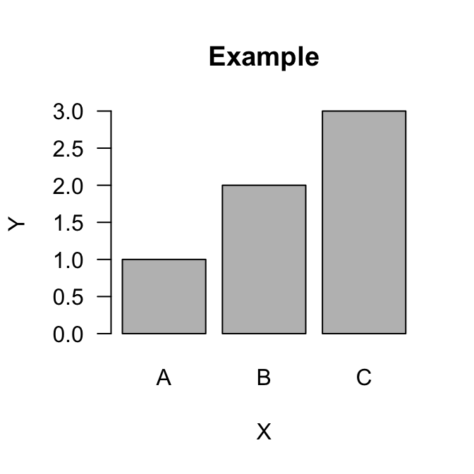

```r
# Example
res <- data.frame(Y = c(1, 2, 3),
                  X = c("A", "B", "C"))
barplot(height = res$Y, names = res$X,
        xlab = "X", ylab = "Y", las = 1,
        main = "Example")
```

## Evaluation

- 5 questions for a total of 100 points
- 1 bonus question for a total of 10 points
[^1]: Classes were paired, but we will ignore that in the analysis